# Loan Default Prediction — Full Code Capstone

## 21. Random Forest

**What it is:**

- An ensemble that fits many decorrelated decision trees on bootstrapped samples with a random subset of features at each split, then averages their votes.

**Why it is relevant here:**

- Random Forests handle mixed data types and missingness signals well and are generally a strong default; I tune `n_estimators`, `max_depth`, and `min_samples_leaf` with 5 fold CV on recall.

```
[Random Forest] best CV recall: 0.7500
[Random Forest] best params: {'clf__max_depth': None, 'clf__min_samples_leaf': 3, 'clf__n_estimators': 500}

=== Random Forest ===
        model  accuracy  precision_1  recall_1   f1_1  roc_auc  pr_auc  cv_recall
Random Forest    0.9013       0.7679    0.7239 0.7452   0.9513  0.8315       0.75

Confusion matrix (rows = actual, cols = predicted):
             Pred 0  Pred 1
Paid (0)       1128      65
Default (1)      82     215
```

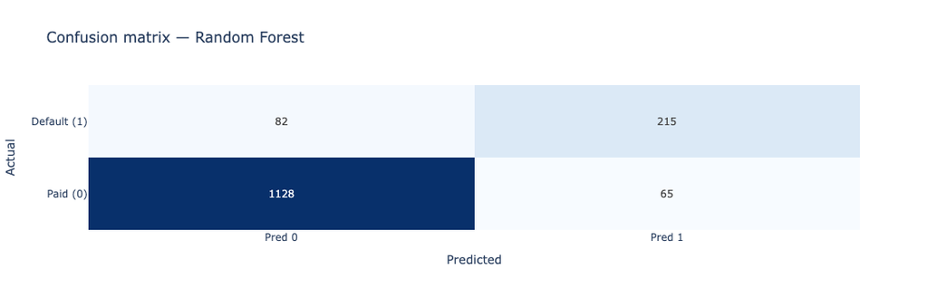

```
{'model': 'Random Forest',
 'accuracy': 0.9013,
 'precision_1': 0.7679,
 'recall_1': 0.7239,
 'f1_1': 0.7452,
 'roc_auc': 0.9513,
 'pr_auc': 0.8315,
 'cv_recall': 0.75}
```

```python
from sklearn.ensemble import RandomForestClassifier

name = "Random Forest"
pipe = Pipeline([
    ("prep", prep_tree),
    ("clf", RandomForestClassifier(
        class_weight="balanced",
        n_jobs=-1,
        random_state=RANDOM_STATE,
    )),
])
param_grid = {
    "clf__n_estimators": [300, 500],
    "clf__max_depth": [None, 15],
    "clf__min_samples_leaf": [1, 3],
}
tune_and_evaluate(name, pipe, param_grid, X_train, y_train, X_test, y_test, results)
```

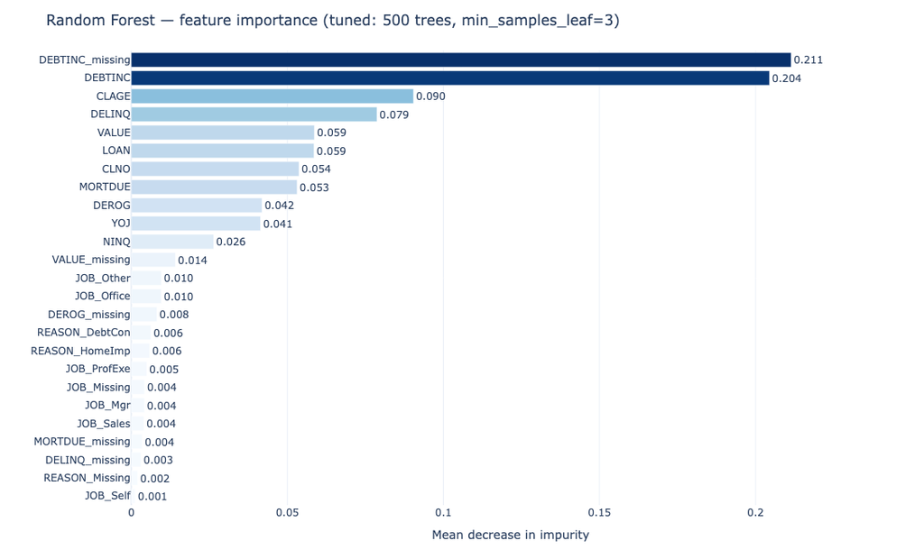

```python
# Random Forest — plotly feature importance chart
# Refits the tuned forest (same params CV picked) so we can visualize what the 500 trees collectively found
from sklearn.ensemble import RandomForestClassifier

rf_viz_pipe = Pipeline([
    ("prep", prep_tree),
    ("clf", RandomForestClassifier(
        n_estimators=500,
        max_depth=None,
        min_samples_leaf=3,
        class_weight="balanced",
        n_jobs=-1,
        random_state=RANDOM_STATE,
    )),
])
rf_viz_pipe.fit(X_train, y_train)

rf_feature_names = rf_viz_pipe.named_steps["prep"].get_feature_names_out()
rf_importances = rf_viz_pipe.named_steps["clf"].feature_importances_

# Strip the ColumnTransformer prefixes (num__, cat__) for readability
clean_names = [n.split("__")[-1] for n in rf_feature_names]

importance_df = (
    pd.DataFrame({"feature": clean_names, "importance": rf_importances})
    .sort_values("importance", ascending=True)
    .reset_index(drop=True)
)

fig = px.bar(
    importance_df,
    x="importance",
    y="feature",
    orientation="h",
    text="importance",
    title="Random Forest — feature importance (tuned: 500 trees, min_samples_leaf=3)",
    labels={"importance": "Mean decrease in impurity", "feature": ""},
    color="importance",
    color_continuous_scale="Blues",
)
fig.update_traces(
    texttemplate="%{text:.3f}",
    textposition="outside",
    cliponaxis=False,
)
fig.update_layout(
    height=650,
    xaxis_range=[0, importance_df["importance"].max() * 1.15],
    coloraxis_showscale=False,
    margin=dict(t=60, l=20, r=40, b=40),
)
fig.show()
```

### Results

- Random Forest caught 215 of 297 actual defaulters for a recall of 72.4 percent after 5 fold stratified CV picked 500 trees with `min_samples_leaf=3` and no depth limit, which is below both Decision Tree (80.1 percent) and Logistic Regression (77.1 percent) despite having the strongest ROC AUC of 0.95 so far.
- Precision on class 1 jumps to 76.8 percent with only 65 false alarms on paid loans, the cleanest precision of any model so far, which tells me the forest's averaging across 500 trees smooths out noise and produces a much more confident "default" call than any single tree.
- The 5 fold CV recall of 0.7500 is almost identical to the held out test recall of 0.7239, a 3 point gap that confirms the forest is stable and not overfitting.
- ROC AUC of 0.95 and PR AUC of 0.83 are the strongest ranking scores of any model yet, so the forest is ordering applicants better than anything else; the recall gap versus the single Decision Tree is purely a threshold effect from the more conservative averaged vote.
- **Key takeaway from the importance chart:** the top two features by a wide margin are `DEBTINC_missing` (0.211) and `DEBTINC` (0.204), which together account for roughly 42 percent of the total impurity reduction across all 500 trees — the single Decision Tree's intuition was right, the DEBTINC signal (both its value and whether it is missing) is the dominant driver of default risk, followed distantly by CLAGE and DELINQ.
- No code changes needed; the forest trades a few points of recall for a large gain in precision and the best ROC AUC so far, and it hands the boosted ensembles in Sections 23 through 26 a clean picture of which features actually matter.

## 22. Bagging Classifier

**What it is:**

- A generic ensemble that fits many copies of the same base learner on bootstrapped samples and averages their predictions.

**Why it is relevant here:**

- Using a pruned Decision Tree as the base gives a useful comparison point to Random Forest (which also adds feature subsampling); I tune the number of estimators with CV.

```
[Bagging Classifier] best CV recall: 0.6984
[Bagging Classifier] best params: {'clf__n_estimators': 100}

=== Bagging Classifier ===
             model  accuracy  precision_1  recall_1   f1_1  roc_auc  pr_auc  cv_recall
Bagging Classifier    0.8899       0.7509      0.67 0.7082   0.9297  0.7877     0.6984

Confusion matrix (rows = actual, cols = predicted):
             Pred 0  Pred 1
Paid (0)       1127      66
Default (1)      98     199
```

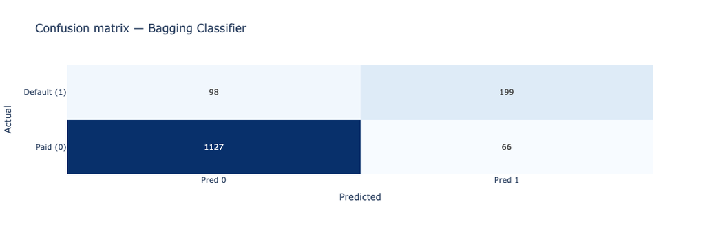

```
{'model': 'Bagging Classifier',
 'accuracy': 0.8899,
 'precision_1': 0.7509,
 'recall_1': 0.67,
 'f1_1': 0.7082,
 'roc_auc': 0.9297,
 'pr_auc': 0.7877,
 'cv_recall': 0.6984}
```

```python
from sklearn.ensemble import BaggingClassifier
from sklearn.tree import DecisionTreeClassifier

name = "Bagging Classifier"
pipe = Pipeline([
    ("prep", prep_tree),
    ("clf", BaggingClassifier(
        estimator=DecisionTreeClassifier(max_depth=10, class_weight="balanced", random_state=RANDOM_STATE),
        n_jobs=-1,
        random_state=RANDOM_STATE,
    )),
])
param_grid = {
    "clf__n_estimators": [100, 200],
}
tune_and_evaluate(name, pipe, param_grid, X_train, y_train, X_test, y_test, results)
```

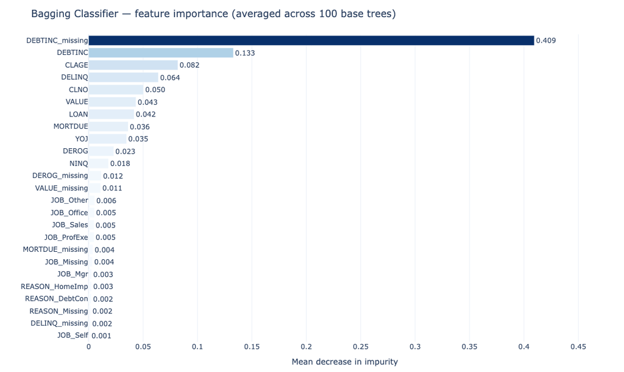

```python
# Bagging Classifier — plotly feature importance chart
# Averages feature_importances_ across all 100 base decision trees
from sklearn.ensemble import BaggingClassifier
from sklearn.tree import DecisionTreeClassifier

bag_viz_pipe = Pipeline([
    ("prep", prep_tree),
    ("clf", BaggingClassifier(
        estimator=DecisionTreeClassifier(max_depth=10, class_weight="balanced", random_state=RANDOM_STATE),
        n_estimators=100,
        n_jobs=-1,
        random_state=RANDOM_STATE,
    )),
])
bag_viz_pipe.fit(X_train, y_train)

bag_feature_names = bag_viz_pipe.named_steps["prep"].get_feature_names_out()
# Average feature_importances_ across all base estimators
base_trees = bag_viz_pipe.named_steps["clf"].estimators_
bag_importances = np.mean([t.feature_importances_ for t in base_trees], axis=0)

clean_names = [n.split("__")[-1] for n in bag_feature_names]

bag_importance_df = (
    pd.DataFrame({"feature": clean_names, "importance": bag_importances})
    .sort_values("importance", ascending=True)
    .reset_index(drop=True)
)

fig = px.bar(
    bag_importance_df,
    x="importance",
    y="feature",
    orientation="h",
    text="importance",
    title="Bagging Classifier — feature importance (averaged across 100 base trees)",
    labels={"importance": "Mean decrease in impurity", "feature": ""},
    color="importance",
    color_continuous_scale="Blues",
)
fig.update_traces(
    texttemplate="%{text:.3f}",
    textposition="outside",
    cliponaxis=False,
)
fig.update_layout(
    height=650,
    xaxis_range=[0, bag_importance_df["importance"].max() * 1.15],
    coloraxis_showscale=False,
    margin=dict(t=60, l=20, r=40, b=40),
)
fig.show()
```

### Results

- Bagging Classifier caught 199 of 297 actual defaulters for a recall of 67.0 percent after 5 fold stratified CV picked `n_estimators=100`, which is below Random Forest (72.4 percent), Decision Tree (80.1 percent), and Logistic Regression (77.1 percent), making this the weakest tree based ensemble so far on the primary metric.
- Precision on class 1 is 75.1 percent with only 66 false alarms on paid loans, essentially tied with Random Forest's 76.8 percent precision, so Bagging is just as confident when it flags an applicant but flags fewer real defaulters.
- The 5 fold CV recall of 0.6984 matches the held out test recall of 0.6700 within 3 points, which confirms the result is stable and not a split artifact.
- ROC AUC of 0.93 is strong but sits below Random Forest's 0.95, which tells me the extra feature subsampling Random Forest does at each split is what buys the ranking advantage — pure bagging of full feature decision trees leaves correlated trees in the ensemble, so averaging them smooths the noise less effectively.
- **Key takeaway from the importance chart:** `DEBTINC_missing` dominates at 0.409 and `DEBTINC` sits at 0.133, so together they absorb 54 percent of the total impurity reduction across the 100 base trees — an even more concentrated picture than Random Forest (where the top two absorbed 42 percent), which is exactly the correlated tree effect I called out above: without feature subsampling, every base tree keeps picking the same two top splits and the ensemble cannot diversify.
- No code changes needed; Bagging's role in the comparison is to isolate the effect of bootstrap aggregation without Random Forest's feature subsampling, and the result cleanly shows that feature subsampling is worth roughly 5 points of recall and 2 points of ROC AUC on this dataset.